# sandbox

```python
import numpy as np
import matplotlib.pyplot as plt
%matplotlib inline
```

### Interpolation

```python
def lerp(v0, v1, a):
    return (1.0 - a) * v0 + (a * v1)

def scurve3(a):
    return (a * a * (3.0 - 2.0 * a))

def scurve5(a):
    a3 = a * a * a
    a4 = a3 * a
    a5 = a4 * a
    return (6.0 * a5) - (15.0 * a4) + (10.0 * a3)
```

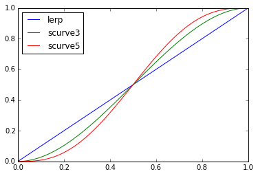

```python
x = np.linspace(0, 1.0, 100)
y1 = lerp(0, 1.0, x)
y2 = scurve3(x)
y3 = scurve5(x)
plt.plot(x, y1, label='lerp')
plt.plot(x, y2, label='scurve3')
plt.plot(x, y3, label='scurve5')
plt.legend(loc=2)
```

### Generating integer noise

The basis for all coherent-noise functions is the integer-noise function. An integer-noise function has three important properties:

- Passing in the same input value will always return the same output value.
- The output value generated by the input value a and the output value generated by the input value b (a != b) will have no correlation with each other.
- The output value will always be within the range -1 to +1.

Below is some code for a one-dimensional integer-noise function:

```python
# This is probably a crappy generator; there was some wrangling involved.
def inoise(n):
    n = n ^ n * 19990303
    nn = (n * (n * n * 60493 + 19990303) + 1376312589) & 0x7fffffff
    return 1.0 - (float(nn) / 1073741824.0)
```

We can visualize this function by plotting it:

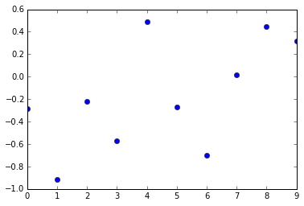

```python
x = [x for x in range(10)]
y1 = [inoise(x) for x in x]
# y2 = [inoise(x + 2) for x in x]
plt.plot(x, y1, 'bo')
# plt.plot(x, y2, 'bo')
```

### Coherent noise

```python
def coherent_noise(x, curve=lambda x: x):
    ix = int(np.floor(x))
    n0 = inoise(ix)
    n1 = inoise(ix + 1)
    w = x - np.floor(x)
    n = lerp(n0, n1, curve(w))
    return n
```

One thing to note about the `coherent_noise` function above is the `curve` parameter. This takes a *curve* function such as `scurve3` or `scurve5`. The default is no curve (just linear interpolation) so we'll give it an `id` lambda.

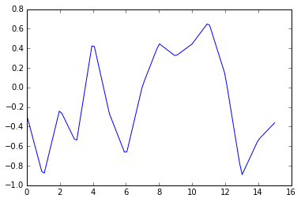

```python
x = np.linspace(0, 15, 100)
y1 = [coherent_noise(x) for x in x]
plt.plot(x, y1, label='linear')
```

Below is a *smoothed* version of the `coherent_noise` function by using the `scurve3` (cubic) curving function.

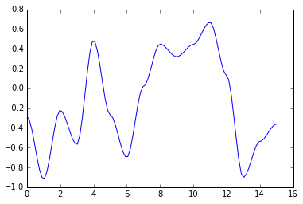

```python
y2 = [coherent_noise(x, scurve3) for x in x]
plt.plot(x, y2, label='cubic')
```

We can be even more smooth by using the (quintic) `scurve5` function:

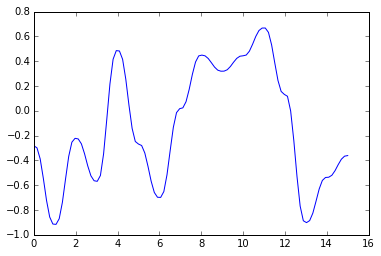

```python
y3 = [coherent_noise(x, scurve5) for x in x]
plt.plot(x, y3, label='quintic')
```